# BMIN503/EPID600 Project Template

Tara Friebel Klingner

### Overview:

For my final project I will be using looking at biological and demographic factors associated with mortality from breast cancer among patients in a cohort from Botswana. Women enrolled into the study between 2015 & 2019. Variables of interest are HIV status, age at diagnosis, stage of tumor at diagnosis, BMI, hormone receptor status, distance from treatment center, marital status and smoking.

### Introduction:

Cancer is a burden around the globe. Looking at the epidemiology of cancer worldwide, there are 18 million incident cancer cases per year and 9.6 million deaths annually. 85% of these deaths occur in low to middle income countries and Africa is disproportionately affected, as is most of sub-Saharan Africa. As motivation for this project, in recognizing the high burden of morbidity and mortality of this disease in Africa and that there is a paucity of research being done focusing on breast cancer incidence and mortality Africa, particularly in Botswana, I will be studying factors associated with mortality from breast cancer. Identifying and reporting on these characteristics will allow a better understanding of cancer in Botswana and will help aid in the direction of resources and help direct future educational and screening interventions. I will use logsitic regression, chi2 tests and other statistical techniques to examine at these factors.

This is a multidisciplinary because it pulls in expertise from chronic diseases, medical oncology, infectious diseases, global oncology, and epidemiology. For a clinical understanding of breast cancer in Botswana I spoke with Surbhi Grover, MD, a radition oncologist in Botswana. To have an understanding of the infectous disease burden, particulrly HIV in Botswana, I spoke with Erle Roberston, PhD, and for global oncology and epidemiology expertise I spoke with Timothy Rebbeck, PhD.

### Methods

In the first paragraph, describe the data used and general methodological approach. Subsequently, incorporate full R code necessary to retrieve and clean data, and perform analysis. Be sure to include a description of code so that others (including your future self) can understand what you are doing and why.

Statistical Analyses will examine differences in mortality and characteristics of breast cancer patients diagnosed from January 2015 through December 2019. Univariate analysis will be used to examine the differences between variables of interest, such as HIV, age, BMI, stage at diagnosis, hormone receptor status, distance from cancer care center, marital status and smoking history. Descriptive statistics will be presented to quantify central tendencies of the data as well as the variability, including the mean of covariates mentioned for breast malignancies presented in the follow-up period. Additional descriptive will include standard deviation, variance, quartiles and minimum and maximum variables for each variable to evaluate the dispersion of data within the BCC. Results will be presented in graphs, plots, and tables to visually demonstrate the distribution and emphasize key features. In addition to chi-square tests for binary and categorical variables, univariate logistic regression, multivariate logistic regression will be used to estimate risk ratios for stage III or IV versus stage I or II stage disease. Covariates found to be significant in the univariate analysis (p<0.20) will be retained in the model for further analysis and possible confounding and interaction between covariates will be explored.

First, I imported the Botswana Cancer Cohort relevant data, using a de-identified and HIPPA compliant .csv file. Next, I will select the outcome and variables of interest, as well as perform and relevant coding and labeling of the variables. For each binary or categorical variable I created a table to see the quantiative statistcs for each variable. For continous variables I obtained the mean and quartile ranges for each. Also, using HIV as a main exposure, I explored relationsips between HIV affected breast cancer patients and HIV unaffacted breast cancer patients with the covariates mentioend above.

When studying health in Botswana, it is important to recognize the high prevalence of HIV in this population. In addition, there are known HIV associated cancers. In this cohort, 28% of the population is HIV positive. Breast cancer is not known to be associated with HIV. However, it remains important to account for this co-morbidity in patients as it may affect their diagnosis, treatment and survival from cancer.

```
## [1] "C:/Users/tfriebel/Documents/test-repo/BMIN503_Final_Project"
```

Variables in the BCC dataset

| record_id | dead | hiv | age | age_group | stage_new | stage_high | distance | hormone | tnb_1 | er | pr | her2 | median_distance | tnb1 | height_cm | weight | bmi | marital_status | smoker | yearofvisit |
| --- | --- | --- | --- | --- | --- | --- | --- | --- | --- | --- | --- | --- | --- | --- | --- | --- | --- | --- | --- | --- |
| 5033 | 0 | 0 | 70 | 3 | NA | NA | 123 | NA | NA | NA | NA | NA | 2 | NA | NA | NA | NA | Single | No | 2016 |
| 449 | 0 | 0 | 36 | 1 | NA | NA | 201 | NA | NA | NA | NA | NA | 0 | NA | 167 | NA | NA | Married | No | 2017 |
| 826 | 0 | 1 | 40 | 1 | 3 | 1 | 437 | 7 | 1 | 0 | 0 | 0 | 0 | 0 | NA | NA | NA | Single | No | 2019 |
| 440 | 0 | 0 | 50 | 2 | NA | NA | 410 | NA | NA | NA | NA | NA | 0 | NA | NA | NA | NA | Married | No | 2017 |
| 728 | 0 | 0 | 73 | 3 | 3 | 1 | 533 | NA | 0 | NA | 0 | 0 | 0 | 0 | NA | NA | NA | Single | No | 2018 |
| 184 | 0 | 0 | 47 | 1 | NA | NA | 161 | NA | NA | NA | NA | NA | 2 | NA | NA | NA | NA | Single | No | 2016 |

[output not shown]

#### Variables & Outcome

From the main dataset, I selected the outcome of interest, mortality, and variables of interest to keep in this analysis. I also assigned labels to some numeric variables.

```r
outcome_exposures<- final_project_BCC %>%
           select("record_id", "marital_status", "smoker", "bmi", "age", "age_group", "hiv", "yearofvisit", "stage_new", "stage_high", "dead", "distance", "er", "pr", "her2", "tnb_1", "hormone") %>%
  mutate(hiv = factor(hiv, levels = c(0, 1), labels = c("HIV unaffected", "HIV affected"))) %>%
  mutate(age_group = factor(age_group, levels = c(1, 2, 3), labels = c("<50", "50-70", ">70"))) %>%
  mutate(stage_high = factor(stage_high, levels = c(0, 1), labels = c("early stage", "late stage"))) %>%
  mutate(dead = factor(dead, levels = c(0, 1), labels = c("Alive", "Deceased"))) %>%
  mutate(smoker = factor(er, levels = c(0, 1), labels = c("Never Smoker", "Ever Smoker"))) %>%
  mutate(er = factor(er, levels = c(0, 1), labels = c("negative", "positive"))) %>%
  mutate(pr = factor(pr, levels = c(0, 1), labels = c("negative", "positive"))) %>%
  mutate(her2 = factor(her2, levels = c(0, 1), labels = c("negative", "positive"))) %>%
  mutate(tnb_1 = factor(tnb_1, levels = c(0, 1), labels = c("negative", "positive"))) %>%
  mutate(hormone = factor(hormone, levels = c(1, 2, 3, 4, 5, 6 ,7), labels = c("ER+", "ER/PR+", "ER/PR/Her2+", "PR+", "PR/Her2+", "Her2+", "tnb")))

kable(head(outcome_exposures), format="pandoc", caption="Variables in the BCC dataset")
```

Variables in the BCC dataset

| record_id | marital_status | smoker | bmi | age | age_group | hiv | yearofvisit | stage_new | stage_high | dead | distance | er | pr | her2 | tnb_1 | hormone |
| --- | --- | --- | --- | --- | --- | --- | --- | --- | --- | --- | --- | --- | --- | --- | --- | --- |
| 5033 | Single | NA | NA | 70 | >70 | HIV unaffected | 2016 | NA | NA | Alive | 123 | NA | NA | NA | NA | NA |
| 449 | Married | NA | NA | 36 | <50 | HIV unaffected | 2017 | NA | NA | Alive | 201 | NA | NA | NA | NA | NA |
| 826 | Single | Never Smoker | NA | 40 | <50 | HIV affected | 2019 | 3 | late stage | Alive | 437 | negative | negative | negative | positive | tnb |
| 440 | Married | NA | NA | 50 | 50-70 | HIV unaffected | 2017 | NA | NA | Alive | 410 | NA | NA | NA | NA | NA |
| 728 | Single | NA | NA | 73 | >70 | HIV unaffected | 2018 | 3 | late stage | Alive | 533 | NA | negative | negative | negative | NA |
| 184 | Single | NA | NA | 47 | <50 | HIV unaffected | 2016 | NA | NA | Alive | 161 | NA | NA | NA | NA | NA |

```r
#filter out missing data
no_missing<-outcome_exposures %>%
  filter(complete.cases(outcome_exposures))

kable(head(no_missing), format="pandoc", caption="Variables in the BCC dataset")
```

Variables in the BCC dataset

| record_id | marital_status | smoker | bmi | age | age_group | hiv | yearofvisit | stage_new | stage_high | dead | distance | er | pr | her2 | tnb_1 | hormone |
| --- | --- | --- | --- | --- | --- | --- | --- | --- | --- | --- | --- | --- | --- | --- | --- | --- |
| 6019 | Single | Ever Smoker | 31 | 61 | 50-70 | HIV unaffected | 2019 | 4 | late stage | Deceased | 68 | positive | negative | negative | negative | ER+ |
| 6120 | Single | Ever Smoker | 21 | 52 | 50-70 | HIV unaffected | 2019 | 3 | late stage | Alive | 47 | positive | positive | negative | negative | ER/PR+ |
| 5439 | Single | Never Smoker | 16 | 38 | <50 | HIV affected | 2017 | 3 | late stage | Deceased | 66 | negative | negative | positive | negative | Her2+ |
| 5693 | Single | Ever Smoker | 18 | 33 | <50 | HIV affected | 2018 | 1 | early stage | Alive | 47 | positive | positive | negative | negative | ER/PR+ |
| 205 | Single | Never Smoker | 19 | 46 | <50 | HIV affected | 2016 | 3 | late stage | Alive | 6 | negative | negative | positive | negative | Her2+ |
| 5670 | Widowed | Never Smoker | 22 | 63 | 50-70 | HIV unaffected | 2018 | 3 | late stage | Alive | 161 | negative | negative | positive | negative | Her2+ |

#### Exploratory analysis

First, I did an exploratory analysis. I took a look at individual variables, then a look at bivariate relationships. Visual plots and quantitative statistics for all variables of interest. For bivariate/categorical variables I used bar plots for visual display.

```r
library(RColorBrewer)
library(viridis)
```

```r
library(ggplot2)
library(devtools)
library(cowplot)
#For dichotomous variables, tables of outcome and variable of interest:
table(outcome_exposures$hiv)
```

```
##
## HIV unaffected   HIV affected
##            263            104
```

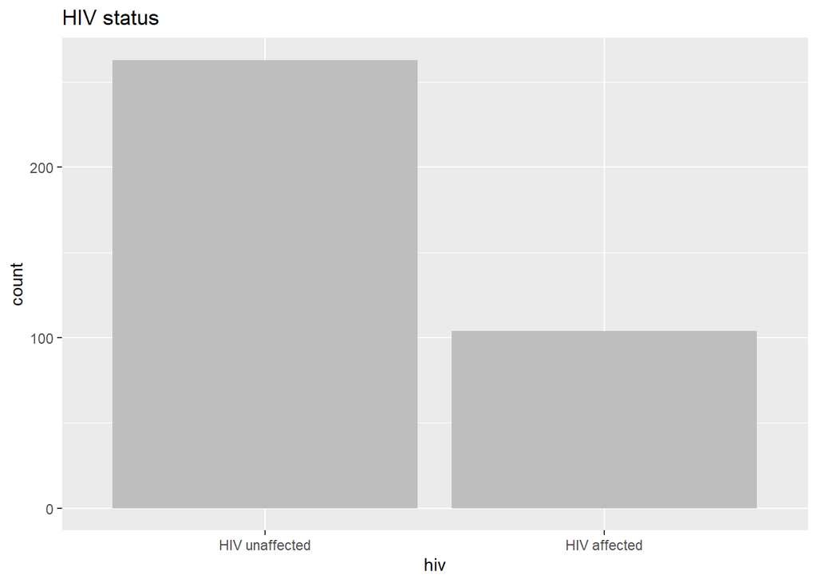

```r
ggplot(data = outcome_exposures, aes(x = hiv)) +
    geom_bar(fill=" grey") +
  ggtitle(paste("HIV status"))
```

```r
table(outcome_exposures$age_group)
```

```
##
##   <50 50-70   >70
##   164   161    42
```

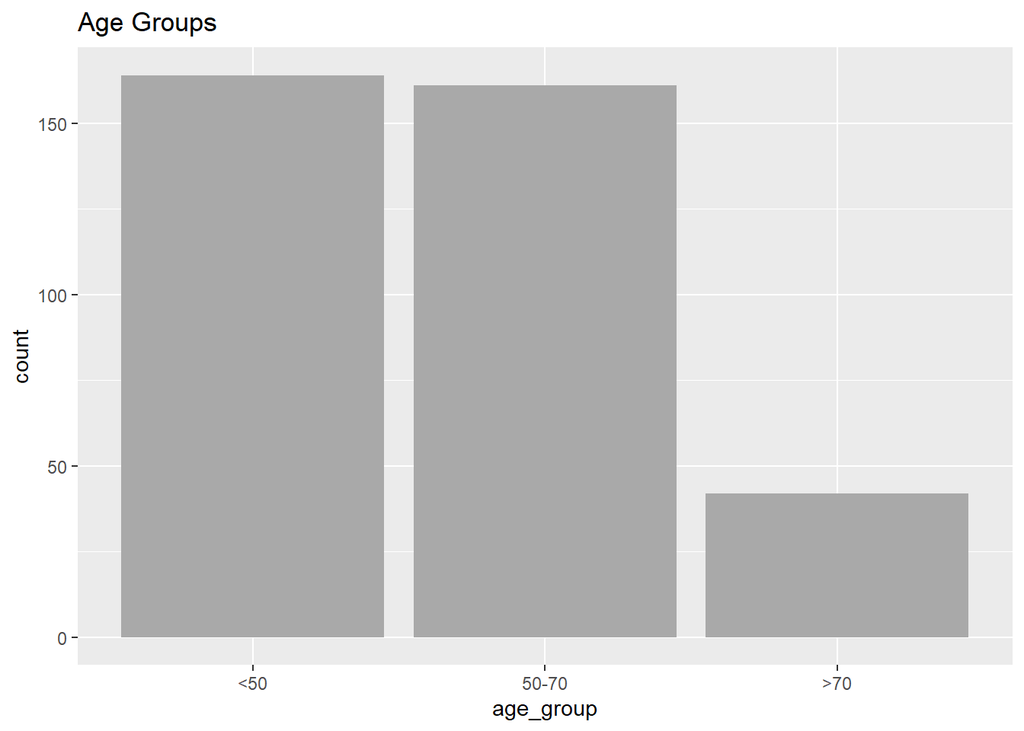

```r
ggplot(data = outcome_exposures, aes(x = age_group)) +
    geom_bar(fill="dark grey") +
  ggtitle(paste("Age Groups"))
```

```r
table(outcome_exposures$stage_high)
```

```
##
## early stage  late stage
##          44         169
```

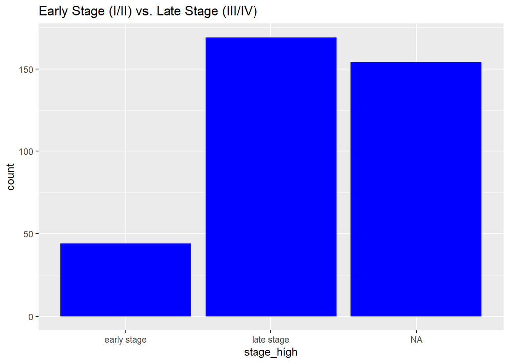

```r
ggplot(data = outcome_exposures, aes(x = stage_high)) +
    geom_bar(fill="blue") +
  ggtitle(paste("Early Stage (I/II) vs. Late Stage (III/IV)"))
```

```r
table(outcome_exposures$er)
```

```
##
## negative positive
##       96      130
```

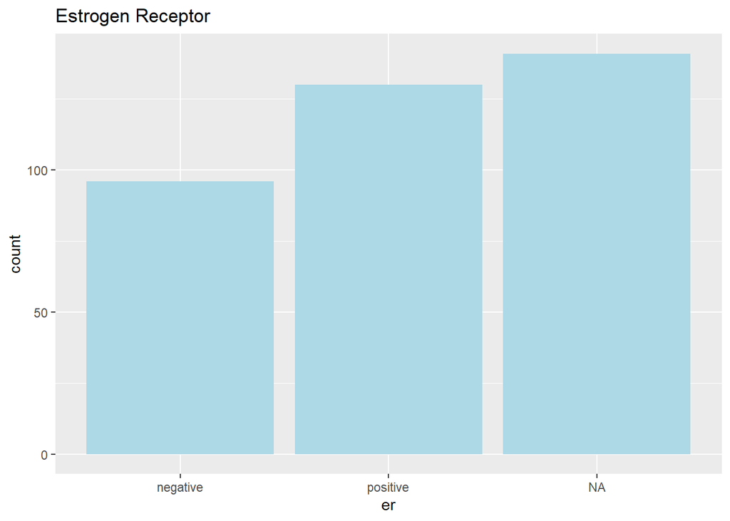

```r
ggplot(data = outcome_exposures, aes(x = er)) +
    geom_bar(fill="light blue") +
  ggtitle(paste("Estrogen Receptor"))
```

```r
table(outcome_exposures$pr)
```

```
##
## negative positive
##      126       95
```

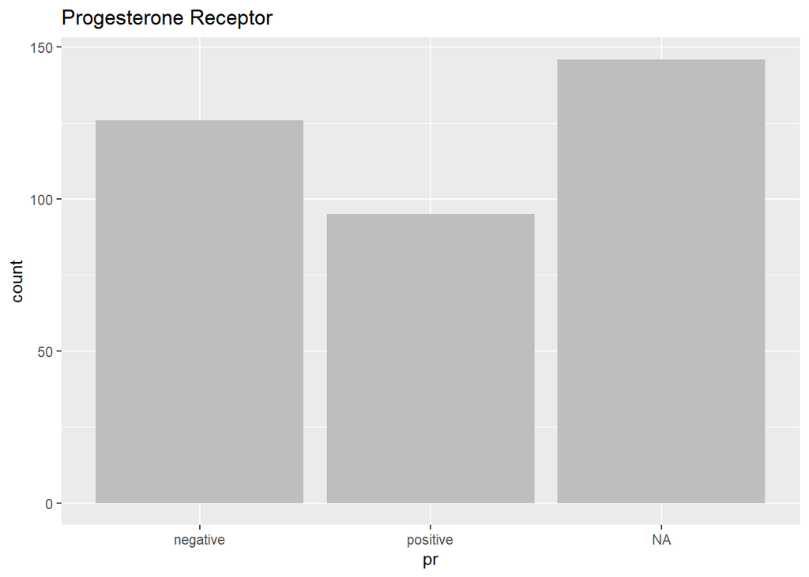

```r
ggplot(data = outcome_exposures, aes(x = pr)) +
    geom_bar(fill="grey") +
  ggtitle(paste("Progesterone Receptor"))
```

```r
table(outcome_exposures$her2)
```

```
##
## negative positive
##      164       53
```

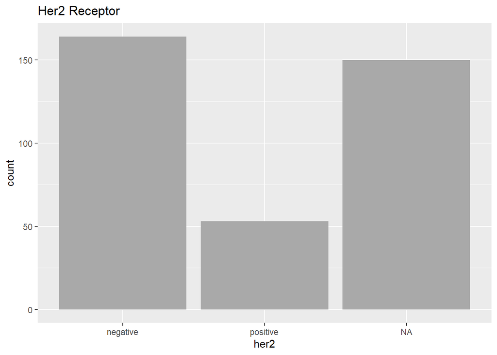

```r
ggplot(data = outcome_exposures, aes(x = her2)) +
    geom_bar(fill="dark grey") +
  ggtitle(paste("Her2 Receptor"))
```

```r
table(outcome_exposures$hormone)
```

```
##
##         ER+      ER/PR+ ER/PR/Her2+         PR+    PR/Her2+       Her2+         tnb
##          34          62          21           4           2          23          52
```

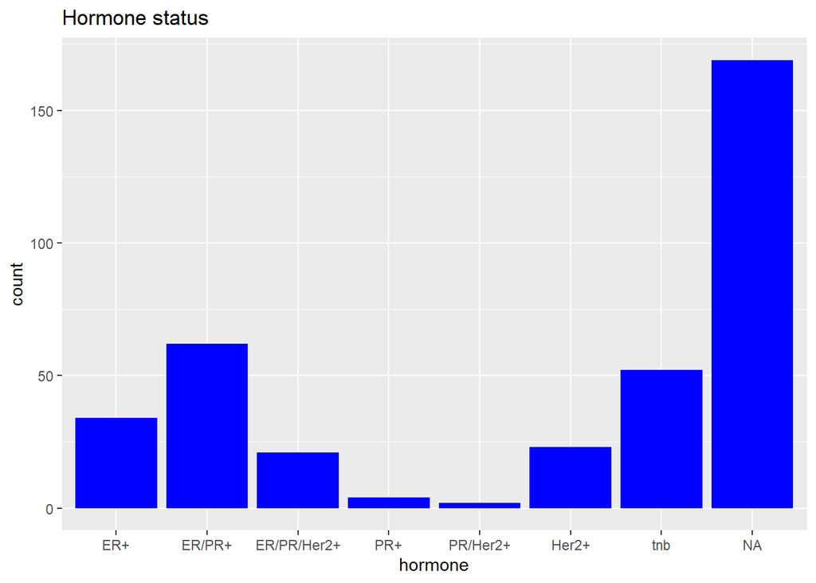

```r
ggplot(data = outcome_exposures, aes(x = hormone)) +
    geom_bar(fill="blue")+
  ggtitle(paste("Hormone status"))
```

```r
table(outcome_exposures$marital_status)
```

```
##
## Divorced  Married   Single  Widowed
##        5      125      191       43
```

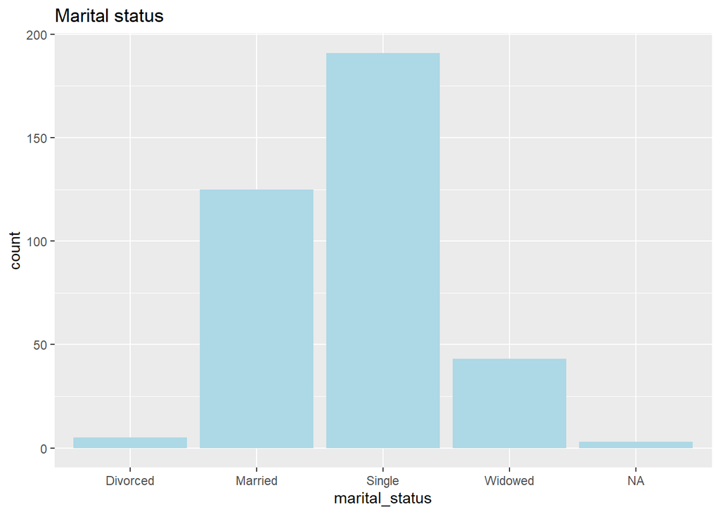

```r
ggplot(data = outcome_exposures, aes(x = marital_status)) +
    geom_bar(fill="light blue") +
  ggtitle(paste("Marital status"))
```

```r
table(outcome_exposures$smoker)
```

```
##
## Never Smoker  Ever Smoker
##           96          130
```

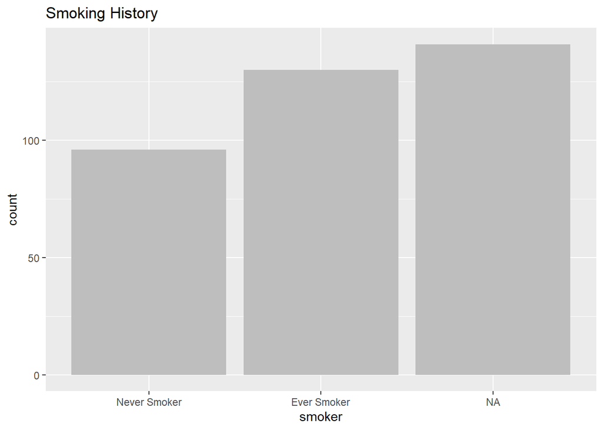

```r
ggplot(data = outcome_exposures, aes(x = smoker)) +
    geom_bar(fill="grey") +
  ggtitle(paste("Smoking History "))
```

```r
table(outcome_exposures$dead)
```

```
##
##    Alive Deceased
##      338       29
```

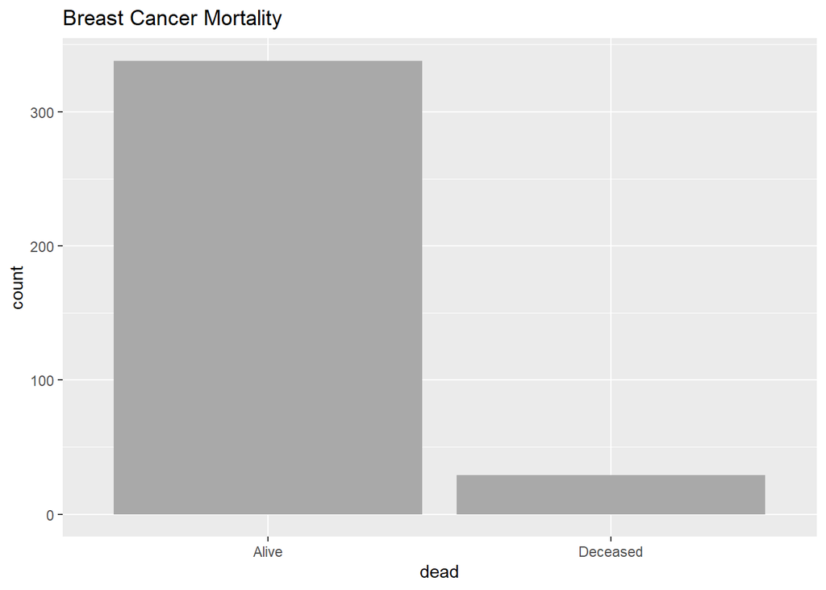

```r
ggplot(data = outcome_exposures, aes(x = dead)) +
    geom_bar(fill="dark grey") +
  ggtitle(paste("Breast Cancer Mortality"))
```

#### Visual plots and quantitative statistics of variables of interest:

To get a sense of the distribution of a continuous variable, I used histograms and density plotsand obtained the mean value of each continuous variable.

```r
summarise(outcome_exposures, age = mean(age, na.rm=TRUE))
```

```
## # A tibble: 1 x 1
##     age
##   <dbl>
## 1  52.7
```

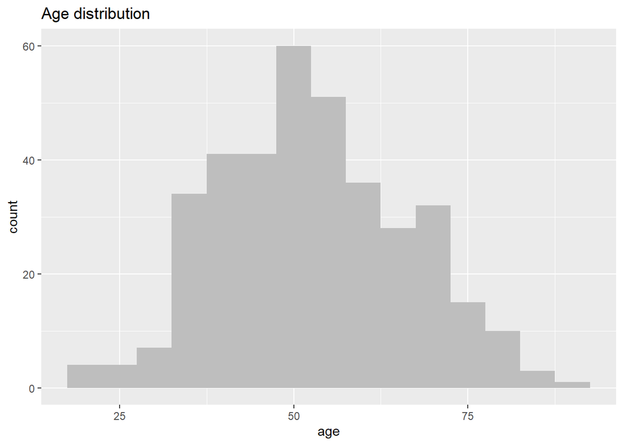

```r
ggplot(data = outcome_exposures, aes(x = age)) +
    geom_histogram(binwidth=5, fill="grey") +
  ggtitle(paste("Age distribution"))
```

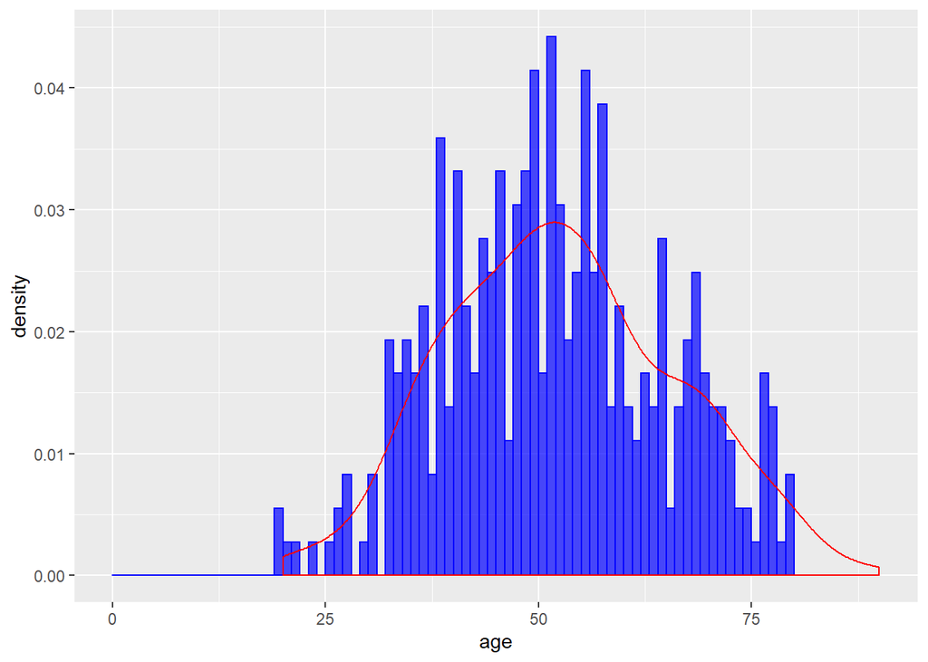

```r
#Density plot
ggplot(data = outcome_exposures, aes(age)) +
    geom_histogram(aes(y = ..density..), breaks = seq(0, 80, 1), color = "blue", fill = "blue", alpha = 0.7) +
    geom_density(color = "red")
```

```r
summarise(outcome_exposures, bmi = mean(bmi, na.rm=TRUE))
```

```
## # A tibble: 1 x 1
##     bmi
##   <dbl>
## 1  31.3
```

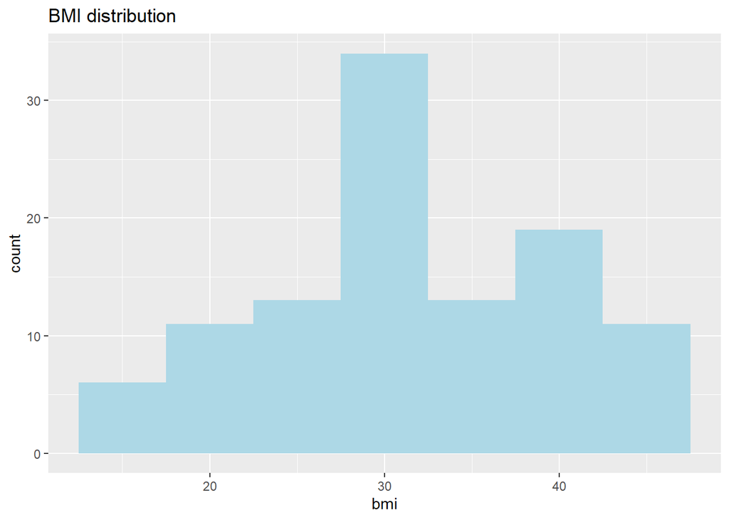

```r
ggplot(data = outcome_exposures, aes(x = bmi)) +
    geom_histogram(binwidth=5, fill="light blue")+
  ggtitle(paste("BMI distribution"))
```

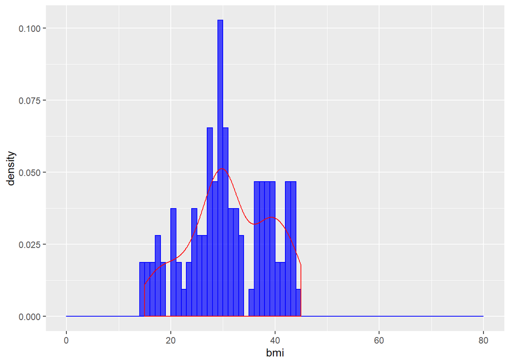

```r
#Density plot
ggplot(data = outcome_exposures, aes(bmi)) +
    geom_histogram(aes(y = ..density..), breaks = seq(0, 80, 1), color = "blue", fill = "blue", alpha = 0.7) +
    geom_density(color = "red")
```

```r
summarise(outcome_exposures, distance = mean(distance, na.rm=TRUE))
```

```
## # A tibble: 1 x 1
##   distance
##      <dbl>
## 1     226.
```

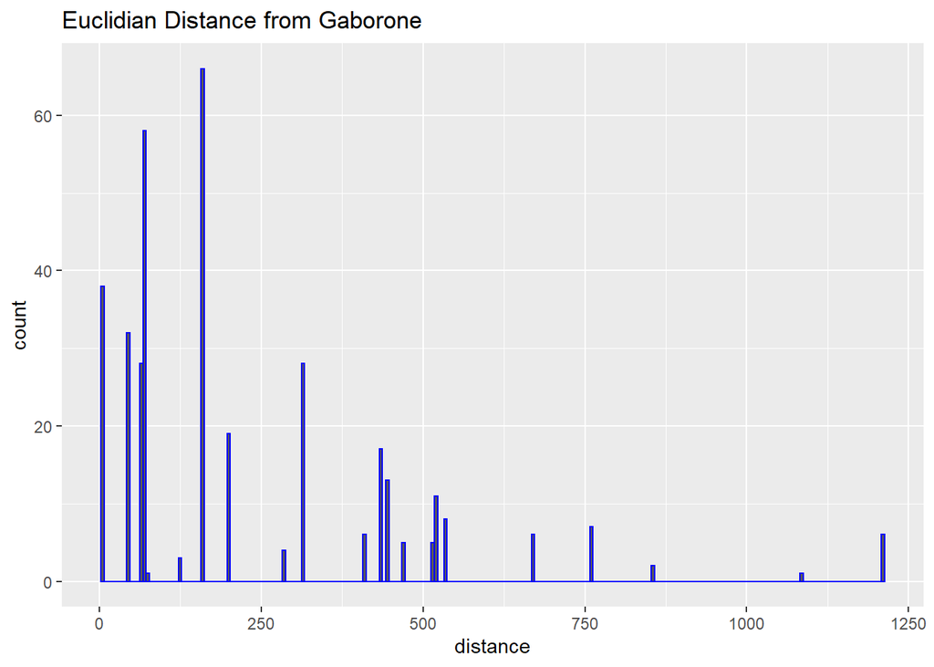

```r
ggplot(data = outcome_exposures, aes(x = distance)) +
  geom_histogram(binwidth=5, color="blue") +
  ggtitle(paste("Euclidian Distance from Gaborone"))
```

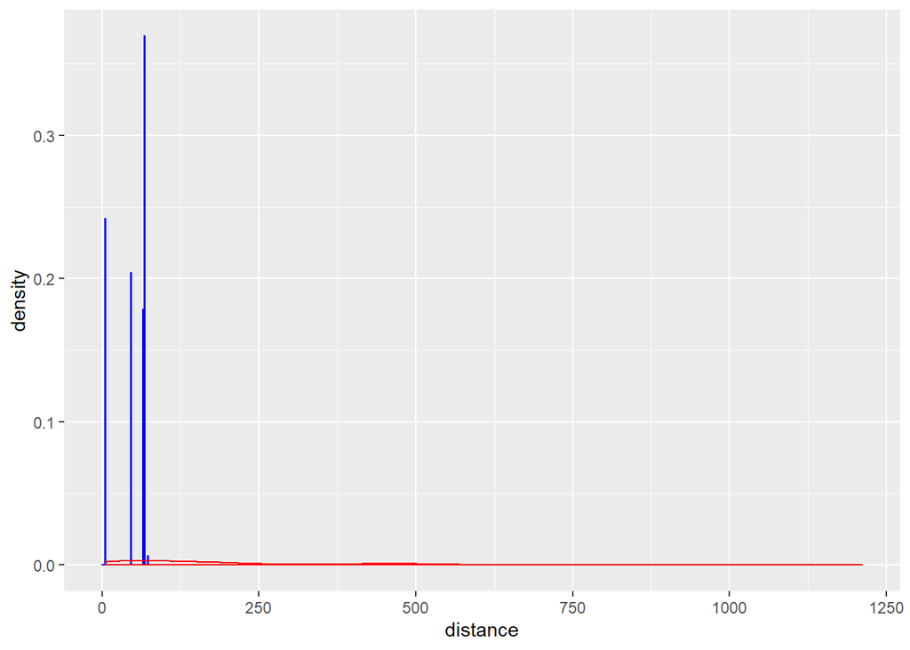

```r
#Density plot
ggplot(data = outcome_exposures, aes(distance)) +
    geom_histogram(aes(y = ..density..), breaks = seq(0, 80, 1), color = "blue", fill = "blue", alpha = 0.7) +
    geom_density(color = "red")
```

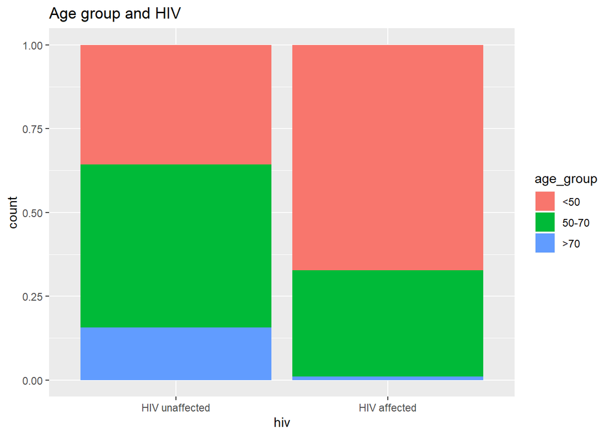

```r
#exploring visual relation ship between main variable (HIV) and covariates of interest
ggplot(data = outcome_exposures, aes(x = hiv, fill=age_group)) +
    geom_bar(position="fill") +
  ggtitle(paste("Age group and HIV"))
```

```r
summary((glm(hiv ~ age_group, data = outcome_exposures, family = binomial())))
```

```
##
## Call:
## glm(formula = hiv ~ age_group, family = binomial(), data = outcome_exposures)
##
## Deviance Residuals:
##     Min       1Q   Median       3Q      Max
## -1.0551  -1.0551  -0.6773   1.3049   2.7341
##
## Coefficients:
##                Estimate Std. Error z value Pr(>|z|)
## (Intercept)     -0.2948     0.1579  -1.867 0.061857 .
## age_group50-70  -1.0607     0.2511  -4.225 2.39e-05 ***
## age_group>70    -3.4188     1.0243  -3.338 0.000845 ***
## ---
## Signif. codes:  0 '***' 0.001 '**' 0.01 '*' 0.05 '.' 0.1 ' ' 1
##
## (Dispersion parameter for binomial family taken to be 1)
##
##     Null deviance: 437.55  on 366  degrees of freedom
## Residual deviance: 396.60  on 364  degrees of freedom
## AIC: 402.6
##
## Number of Fisher Scoring iterations: 6
```

```r
exp(coef(glm(hiv ~ age_group, data = outcome_exposures, family = binomial()))) #Odds ratio
```

```
##    (Intercept) age_group50-70   age_group>70
##     0.74468085     0.34620536     0.03275261
```

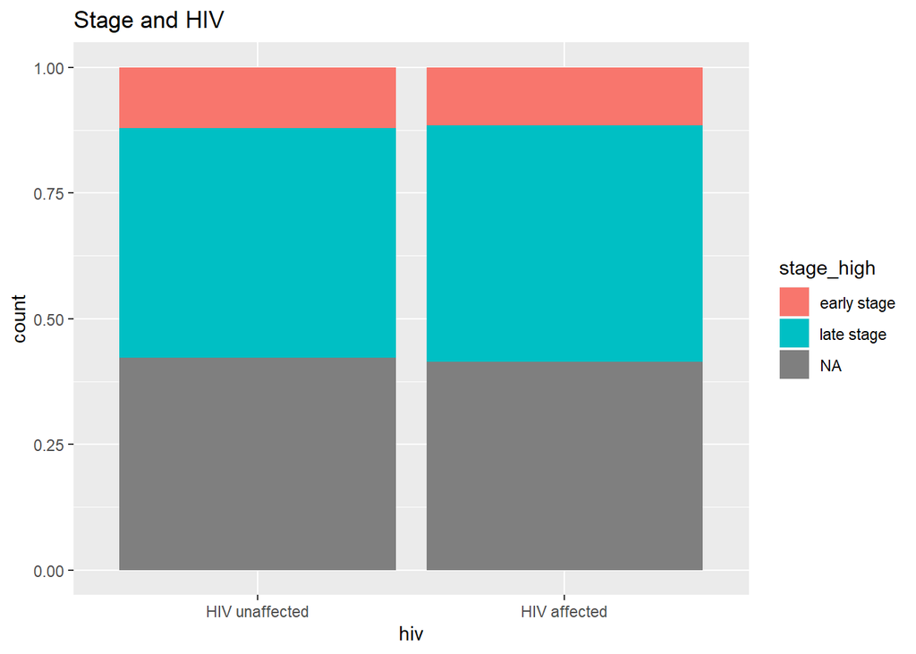

```r
ggplot(data = outcome_exposures, aes(x = hiv, fill=stage_high)) +
    geom_bar(position="fill") +
  ggtitle(paste("Stage and HIV"))
```

```r
summary((glm(hiv ~ stage_high, data = outcome_exposures, family = binomial())))
```

```
##
## Call:
## glm(formula = hiv ~ stage_high, family = binomial(), data = outcome_exposures)
##
## Deviance Residuals:
##     Min       1Q   Median       3Q      Max
## -0.8275  -0.8275  -0.8275   1.5736   1.6120
##
## Coefficients:
##                      Estimate Std. Error z value Pr(>|z|)
## (Intercept)          -0.98083    0.33850  -2.898  0.00376 **
## stage_highlate stage  0.08516    0.37858   0.225  0.82203
## ---
## Signif. codes:  0 '***' 0.001 '**' 0.01 '*' 0.05 '.' 0.1 ' ' 1
##
## (Dispersion parameter for binomial family taken to be 1)
##
##     Null deviance: 255.12  on 212  degrees of freedom
## Residual deviance: 255.07  on 211  degrees of freedom
##   (154 observations deleted due to missingness)
## AIC: 259.07
##
## Number of Fisher Scoring iterations: 4
```

```r
exp(coef(glm(hiv ~ stage_high, data = outcome_exposures, family = binomial()))) #Odds ratio
```

```
##          (Intercept) stage_highlate stage
##             0.375000             1.088889
```

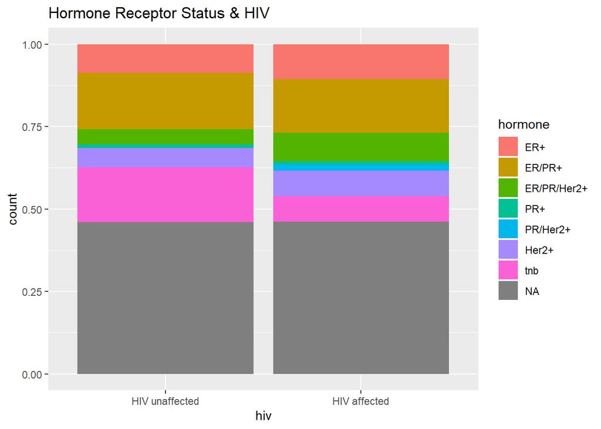

```r
ggplot(data = outcome_exposures, aes(x = hiv, fill=hormone)) +
    geom_bar(position="fill") +
  ggtitle(paste("Hormone Receptor Status & HIV"))
```

```r
summary((glm(hiv ~ hormone, data = outcome_exposures, family = binomial())))
```

```
##
## Call:
## glm(formula = hiv ~ hormone, family = binomial(), data = outcome_exposures)
##
## Deviance Residuals:
##     Min       1Q   Median       3Q      Max
## -1.0579  -0.8633  -0.5780   1.3018   1.9348
##
## Coefficients:
##                     Estimate Std. Error z value Pr(>|z|)
## (Intercept)          -0.7376     0.3666  -2.012   0.0442 *
## hormoneER/PR+        -0.2359     0.4641  -0.508   0.6114
## hormoneER/PR/Her2+    0.4499     0.5734   0.785   0.4327
## hormonePR+           -0.3610     1.2115  -0.298   0.7657
## hormonePR/Her2+      16.3037  1029.1215   0.016   0.9874
## hormoneHer2+          0.1090     0.5710   0.191   0.8486
## hormonetnb           -0.9671     0.5311  -1.821   0.0686 .
## ---
## Signif. codes:  0 '***' 0.001 '**' 0.01 '*' 0.05 '.' 0.1 ' ' 1
##
## (Dispersion parameter for binomial family taken to be 1)
##
##     Null deviance: 235.86  on 197  degrees of freedom
## Residual deviance: 223.19  on 191  degrees of freedom
##   (169 observations deleted due to missingness)
## AIC: 237.19
##
## Number of Fisher Scoring iterations: 14
```

```r
exp(coef(glm(hiv ~ hormone, data = outcome_exposures, family = binomial()))) #Odds ratio
```

```
##        (Intercept)      hormoneER/PR+ hormoneER/PR/Her2+         hormonePR+    hormonePR/Her2+       hormoneHer2+         hormonetnb
##       4.782609e-01       7.898990e-01       1.568182e+00       6.969697e-01       1.203906e+07       1.115152e+00       3.801653e-01
```

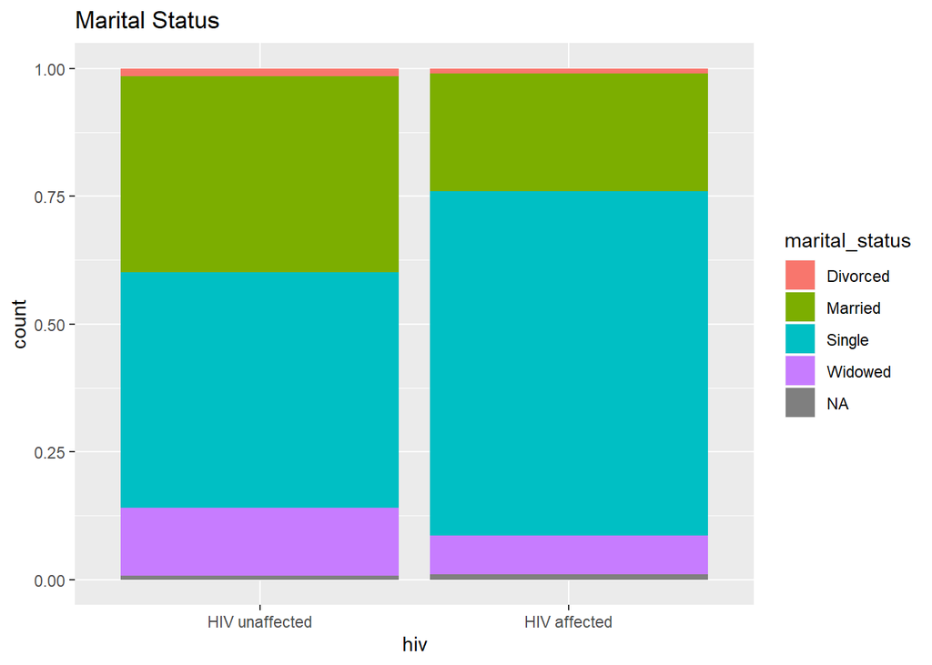

```r
ggplot(data = outcome_exposures, aes(x = hiv, fill=marital_status)) +
    geom_bar(position="fill") +
  ggtitle(paste("Marital Status"))
```

```r
summary((glm(hiv ~ marital_status, data = outcome_exposures, family = binomial())))
```

```
##
## Call:
## glm(formula = hiv ~ marital_status, family = binomial(), data = outcome_exposures)
##
## Deviance Residuals:
##     Min       1Q   Median       3Q      Max
## -0.9555  -0.9555  -0.6530   1.4169   1.8340
##
## Coefficients:
##                       Estimate Std. Error z value Pr(>|z|)
## (Intercept)           -1.38629    1.11803  -1.240    0.215
## marital_statusMarried -0.05077    1.14086  -0.045    0.965
## marital_statusSingle   0.83900    1.12807   0.744    0.457
## marital_statusWidowed -0.08961    1.18472  -0.076    0.940
##
## (Dispersion parameter for binomial family taken to be 1)
##
##     Null deviance: 433.69  on 363  degrees of freedom
## Residual deviance: 419.60  on 360  degrees of freedom
##   (3 observations deleted due to missingness)
## AIC: 427.6
##
## Number of Fisher Scoring iterations: 4
```

```r
exp(coef(glm(hiv ~ marital_status, data = outcome_exposures, family = binomial()))) #Odds ratio
```

```
##           (Intercept) marital_statusMarried  marital_statusSingle marital_statusWidowed
##             0.2500000             0.9504950             2.3140496             0.9142857
```

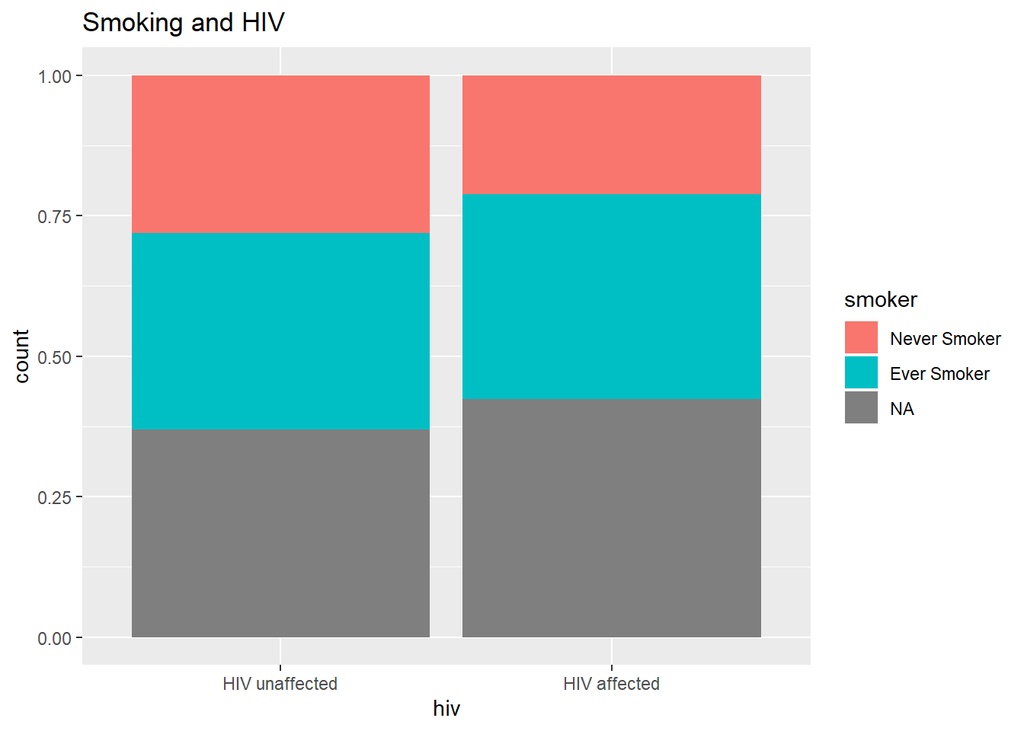

```r
ggplot(data = outcome_exposures, aes(x = hiv, fill=smoker)) +
    geom_bar(position="fill") +
  ggtitle(paste("Smoking and HIV"))
```

```r
summary((glm(hiv ~ smoker, data = outcome_exposures, family = binomial())))
```

```
##
## Call:
## glm(formula = hiv ~ smoker, family = binomial(), data = outcome_exposures)
##
## Deviance Residuals:
##     Min       1Q   Median       3Q      Max
## -0.8316  -0.8316  -0.7215   1.5684   1.7166
##
## Coefficients:
##                   Estimate Std. Error z value Pr(>|z|)
## (Intercept)        -1.2130     0.2428  -4.995 5.87e-07 ***
## smokerEver Smoker   0.3288     0.3101   1.060    0.289
## ---
## Signif. codes:  0 '***' 0.001 '**' 0.01 '*' 0.05 '.' 0.1 ' ' 1
##
## (Dispersion parameter for binomial family taken to be 1)
##
##     Null deviance: 261.58  on 225  degrees of freedom
## Residual deviance: 260.44  on 224  degrees of freedom
##   (141 observations deleted due to missingness)
## AIC: 264.44
##
## Number of Fisher Scoring iterations: 4
```

```r
exp(coef(glm(hiv ~ smoker, data = outcome_exposures, family = binomial()))) #Odds ratio
```

```
##       (Intercept) smokerEver Smoker
##         0.2972973         1.3893281
```

#### Boxplots for continuous predictors

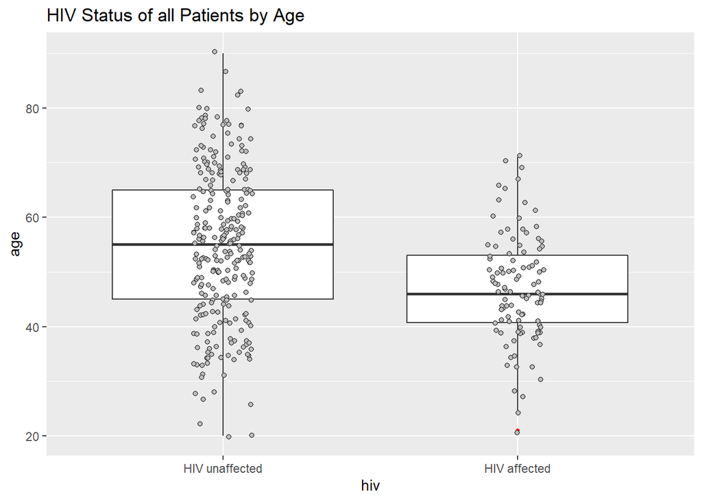

```r
ggplot(data = outcome_exposures, aes(hiv, age)) +
    geom_boxplot(outlier.colour = "red", outlier.size = 1) +
  geom_jitter(width=0.1, pch=21, fill="grey", na.rm=TRUE) +
  ggtitle(paste("HIV Status of all Patients by Age"))
```

```r
summary((glm(hiv ~ age, data = outcome_exposures, family = binomial())))
```

```
##
## Call:
## glm(formula = hiv ~ age, family = binomial(), data = outcome_exposures)
##
## Deviance Residuals:
##     Min       1Q   Median       3Q      Max
## -1.4265  -0.8316  -0.6308   1.2873   2.0201
##
## Coefficients:
##             Estimate Std. Error z value Pr(>|z|)
## (Intercept)  1.53724    0.50093   3.069  0.00215 **
## age         -0.04843    0.00987  -4.907 9.27e-07 ***
## ---
## Signif. codes:  0 '***' 0.001 '**' 0.01 '*' 0.05 '.' 0.1 ' ' 1
##
## (Dispersion parameter for binomial family taken to be 1)
##
##     Null deviance: 437.55  on 366  degrees of freedom
## Residual deviance: 410.37  on 365  degrees of freedom
## AIC: 414.37
##
## Number of Fisher Scoring iterations: 4
```

```r
exp(coef(glm(hiv ~ age, data = outcome_exposures, family = binomial()))) #Odds ratio
```

```
## (Intercept)         age
##   4.6517190   0.9527267
```

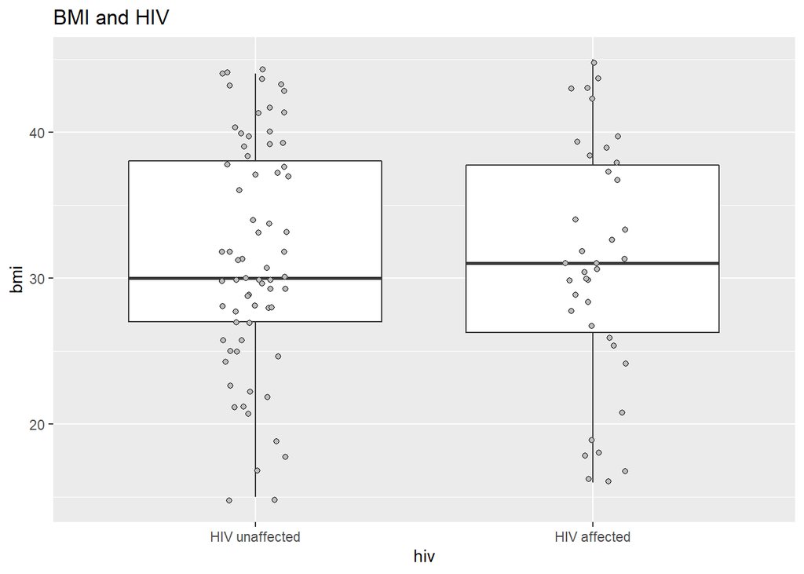

```r
ggplot(data = outcome_exposures, aes(hiv, bmi)) +
    geom_boxplot(outlier.colour = "red", outlier.size = 1) +
  geom_jitter(width=0.1, pch=21, fill="grey", na.rm=TRUE) +
  ggtitle(paste("BMI and HIV"))
```

```r
summary((glm(hiv ~ bmi, data = outcome_exposures, family = binomial())))
```

```
##
## Call:
## glm(formula = hiv ~ bmi, family = binomial(), data = outcome_exposures)
##
## Deviance Residuals:
##     Min       1Q   Median       3Q      Max
## -1.0025  -0.9455  -0.9060   1.4215   1.5041
##
## Coefficients:
##             Estimate Std. Error z value Pr(>|z|)
## (Intercept) -0.26881    0.82220  -0.327    0.744
## bmi         -0.01051    0.02562  -0.410    0.682
##
## (Dispersion parameter for binomial family taken to be 1)
##
##     Null deviance: 139.22  on 106  degrees of freedom
## Residual deviance: 139.05  on 105  degrees of freedom
##   (260 observations deleted due to missingness)
## AIC: 143.05
##
## Number of Fisher Scoring iterations: 4
```

```r
exp(coef(glm(hiv ~ bmi, data = outcome_exposures, family = binomial())))
```

```
## (Intercept)         bmi
##   0.7642919   0.9895499
```

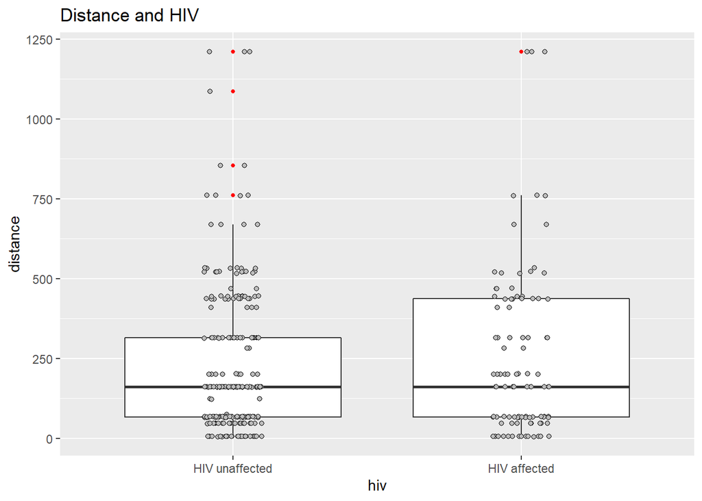

```r
ggplot(data = outcome_exposures, aes(hiv, distance)) +
     geom_boxplot(outlier.colour = "red", outlier.size = 1) +
  geom_jitter(width=0.1, pch=21, fill="grey", na.rm=TRUE) +
  ggtitle(paste("Distance and HIV"))
```

```r
summary((glm(hiv ~ distance, data = outcome_exposures, family = binomial())))
```

```
##
## Call:
## glm(formula = hiv ~ distance, family = binomial(), data = outcome_exposures)
##
## Deviance Residuals:
##     Min       1Q   Median       3Q      Max
## -1.0139  -0.7972  -0.7796   1.5226   1.6522
##
## Coefficients:
##               Estimate Std. Error z value Pr(>|z|)
## (Intercept) -1.0732943  0.1632180  -6.576 4.84e-11 ***
## distance     0.0005581  0.0004768   1.171    0.242
## ---
## Signif. codes:  0 '***' 0.001 '**' 0.01 '*' 0.05 '.' 0.1 ' ' 1
##
## (Dispersion parameter for binomial family taken to be 1)
##
##     Null deviance: 431.82  on 363  degrees of freedom
## Residual deviance: 430.48  on 362  degrees of freedom
##   (3 observations deleted due to missingness)
## AIC: 434.48
##
## Number of Fisher Scoring iterations: 4
```

```r
exp(coef(glm(hiv ~ distance, data = outcome_exposures, family = binomial())))
```

```
## (Intercept)    distance
##   0.3418804   1.0005583
```

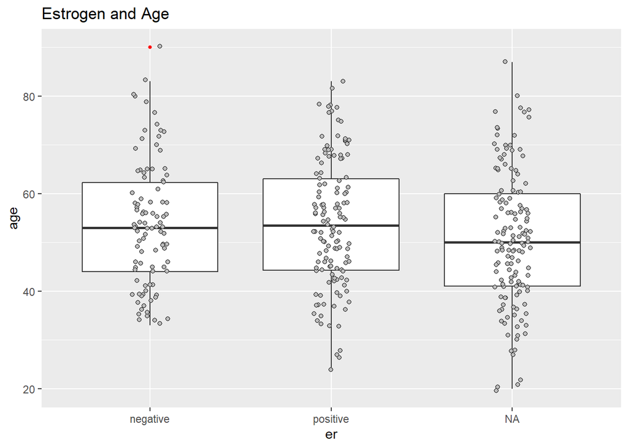

```r
##Exploring Hormone Status across the age distribution of the cohort
ggplot(data = outcome_exposures, aes(er, age)) +
     geom_boxplot(outlier.colour = "red", outlier.size = 1) +
  geom_jitter(width=0.1, pch=21, fill="grey", na.rm=TRUE) +
  ggtitle(paste("Estrogen and Age"))
```

```r
summary((glm(er ~ age, data = outcome_exposures, family = binomial())))
```

```
##
## Call:
## glm(formula = er ~ age, family = binomial(), data = outcome_exposures)
##
## Deviance Residuals:
##    Min      1Q  Median      3Q     Max
## -1.319  -1.308   1.047   1.052   1.060
##
## Coefficients:
##             Estimate Std. Error z value Pr(>|z|)
## (Intercept)  0.26708    0.57479   0.465    0.642
## age          0.00067    0.01037   0.065    0.948
##
## (Dispersion parameter for binomial family taken to be 1)
##
##     Null deviance: 308.17  on 225  degrees of freedom
## Residual deviance: 308.16  on 224  degrees of freedom
##   (141 observations deleted due to missingness)
## AIC: 312.16
##
## Number of Fisher Scoring iterations: 4
```

```r
exp(coef(glm(er ~ age, data = outcome_exposures, family = binomial())))
```

```
## (Intercept)         age
##    1.306146    1.000670
```

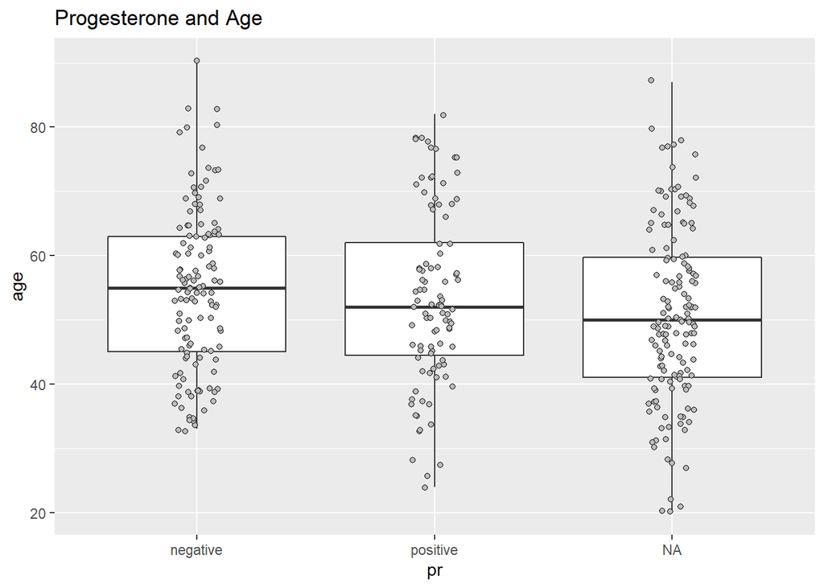

```r
ggplot(data = outcome_exposures, aes(pr, age)) +
     geom_boxplot(outlier.colour = "red", outlier.size = 1) +
  geom_jitter(width=0.1, pch=21, fill="grey", na.rm=TRUE) +
  ggtitle(paste("Progesterone and Age"))
```

```r
summary((glm(pr ~ age, data = outcome_exposures, family = binomial())))
```

```
##
## Call:
## glm(formula = pr ~ age, family = binomial(), data = outcome_exposures)
##
## Deviance Residuals:
##    Min      1Q  Median      3Q     Max
## -1.117  -1.063  -1.020   1.288   1.382
##
## Coefficients:
##              Estimate Std. Error z value Pr(>|z|)
## (Intercept)  0.077276   0.581324   0.133    0.894
## age         -0.006662   0.010484  -0.635    0.525
##
## (Dispersion parameter for binomial family taken to be 1)
##
##     Null deviance: 302.01  on 220  degrees of freedom
## Residual deviance: 301.60  on 219  degrees of freedom
##   (146 observations deleted due to missingness)
## AIC: 305.6
##
## Number of Fisher Scoring iterations: 4
```

```r
exp(coef(glm(pr ~ age, data = outcome_exposures, family = binomial()))) #Odds ratio
```

```
## (Intercept)         age
##   1.0803407   0.9933604
```

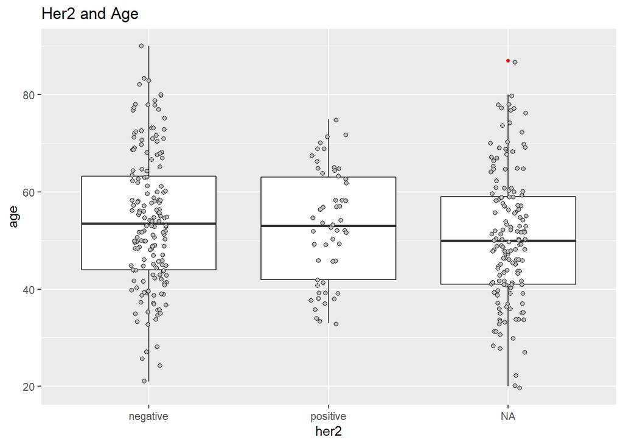

```r
ggplot(data = outcome_exposures, aes(her2, age)) +
     geom_boxplot(outlier.colour = "red", outlier.size = 1) +
  geom_jitter(width=0.1, pch=21, fill="grey", na.rm=TRUE) +
  ggtitle(paste("Her2 and Age"))
```

```r
summary((glm(her2 ~ age, data = outcome_exposures, family = binomial())))
```

```
##
## Call:
## glm(formula = her2 ~ age, family = binomial(), data = outcome_exposures)
##
## Deviance Residuals:
##     Min       1Q   Median       3Q      Max
## -0.8297  -0.7621  -0.7380  -0.6804   1.7495
##
## Coefficients:
##              Estimate Std. Error z value Pr(>|z|)
## (Intercept) -0.735013   0.661900   -1.11    0.267
## age         -0.007351   0.012048   -0.61    0.542
##
## (Dispersion parameter for binomial family taken to be 1)
##
##     Null deviance: 241.27  on 216  degrees of freedom
## Residual deviance: 240.89  on 215  degrees of freedom
##   (150 observations deleted due to missingness)
## AIC: 244.89
##
## Number of Fisher Scoring iterations: 4
```

```r
exp(coef(glm(her2 ~ age, data = outcome_exposures, family = binomial())))
```

```
## (Intercept)         age
##   0.4794990   0.9926757
```

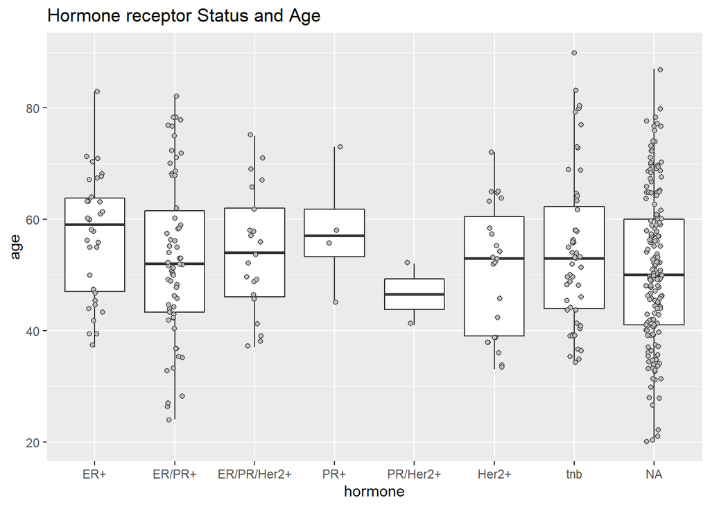

```r
ggplot(data = outcome_exposures, aes(hormone, age)) +
     geom_boxplot(outlier.colour = "red", outlier.size = 1) +
  geom_jitter(width=0.1, pch=21, fill="grey", na.rm=TRUE) +
  ggtitle(paste("Hormone receptor Status and Age"))
```

```r
summary((glm(hormone ~ age, data = outcome_exposures, family = binomial())))
```

```
##
## Call:
## glm(formula = hormone ~ age, family = binomial(), data = outcome_exposures)
##
## Deviance Residuals:
##     Min       1Q   Median       3Q      Max
## -2.0427   0.5149   0.5844   0.6310   0.8467
##
## Coefficients:
##             Estimate Std. Error z value Pr(>|z|)
## (Intercept)  2.73041    0.83123   3.285  0.00102 **
## age         -0.02099    0.01438  -1.459  0.14446
## ---
## Signif. codes:  0 '***' 0.001 '**' 0.01 '*' 0.05 '.' 0.1 ' ' 1
##
## (Dispersion parameter for binomial family taken to be 1)
##
##     Null deviance: 181.61  on 197  degrees of freedom
## Residual deviance: 179.47  on 196  degrees of freedom
##   (169 observations deleted due to missingness)
## AIC: 183.47
##
## Number of Fisher Scoring iterations: 4
```

```r
exp(coef(glm(hormone ~ age, data = outcome_exposures, family = binomial())))
```

```
## (Intercept)         age
##  15.3392134   0.9792295
```

#### Histogram

To get a sense of the distribution of a continuous variable, I used histograms.

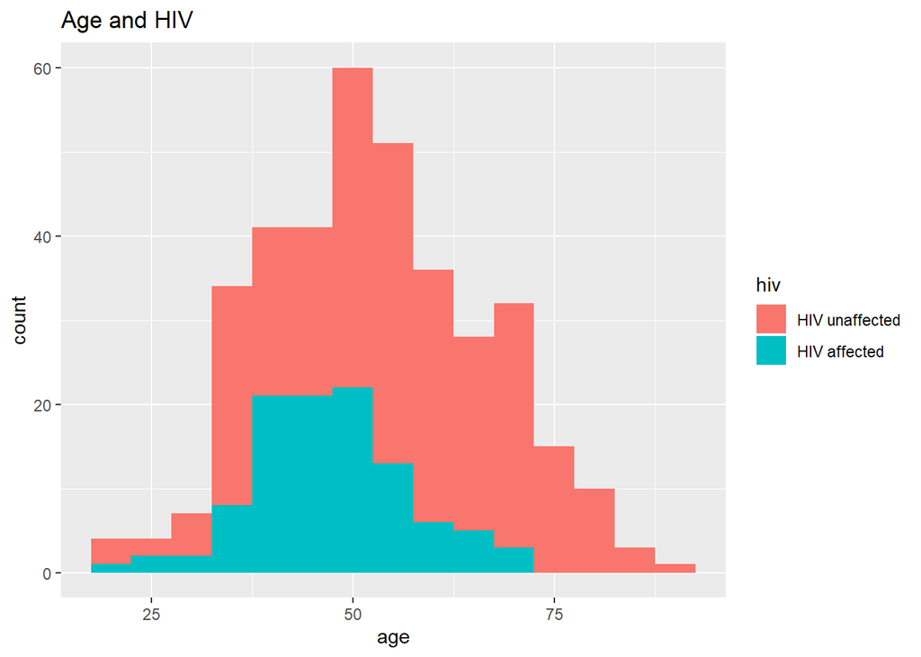

```r
ggplot(data = outcome_exposures, aes(x = age, fill=hiv)) +
    geom_histogram(binwidth=5)+
  ggtitle(paste("Age and HIV"))
```

```r
summary((glm(hiv ~ age, data = outcome_exposures, family = binomial())))
```

```
##
## Call:
## glm(formula = hiv ~ age, family = binomial(), data = outcome_exposures)
##
## Deviance Residuals:
##     Min       1Q   Median       3Q      Max
## -1.4265  -0.8316  -0.6308   1.2873   2.0201
##
## Coefficients:
##             Estimate Std. Error z value Pr(>|z|)
## (Intercept)  1.53724    0.50093   3.069  0.00215 **
## age         -0.04843    0.00987  -4.907 9.27e-07 ***
## ---
## Signif. codes:  0 '***' 0.001 '**' 0.01 '*' 0.05 '.' 0.1 ' ' 1
##
## (Dispersion parameter for binomial family taken to be 1)
##
##     Null deviance: 437.55  on 366  degrees of freedom
## Residual deviance: 410.37  on 365  degrees of freedom
## AIC: 414.37
##
## Number of Fisher Scoring iterations: 4
```

```r
exp(coef(glm(hiv ~ age, data = outcome_exposures, family = binomial()))) #Odds ratio
```

```
## (Intercept)         age
##   4.6517190   0.9527267
```

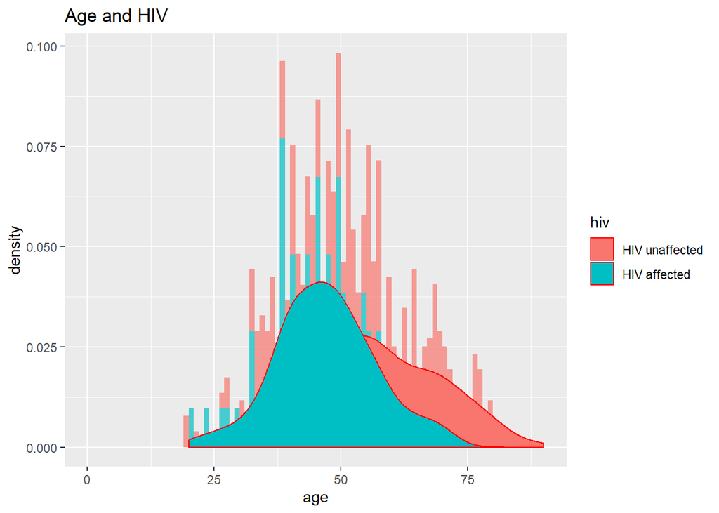

```r
ggplot(data = outcome_exposures, aes(age, fill=hiv)) +
    geom_histogram(aes(y = ..density..), breaks = seq(0, 80, 1), alpha = 0.7) +
    geom_density(color = "red") +
  ggtitle(paste("Age and HIV"))
```

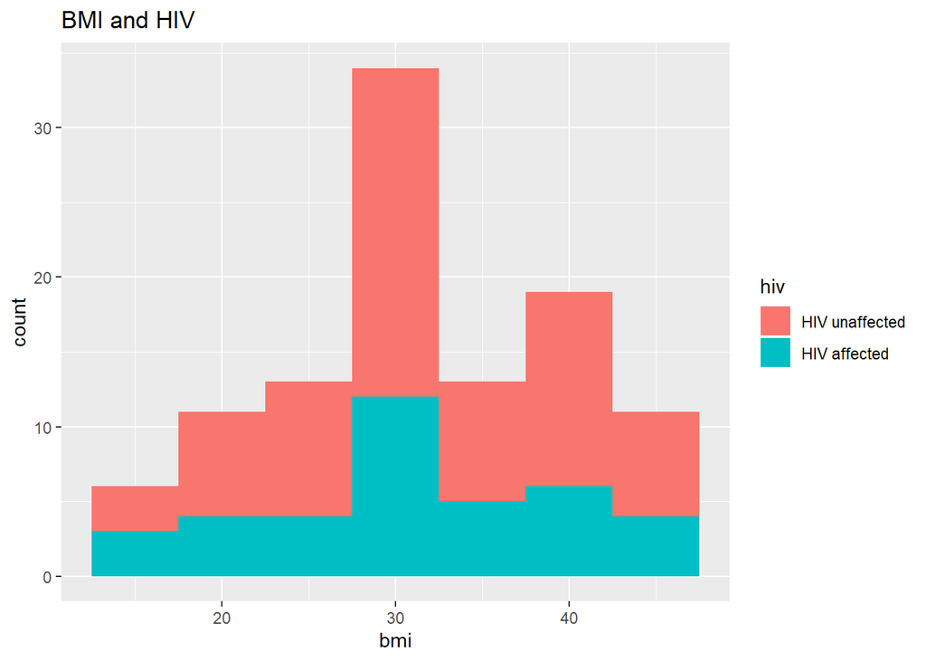

```r
ggplot(data = outcome_exposures, aes(x = bmi, fill=hiv)) +
    geom_histogram(binwidth=5) +
  ggtitle(paste("BMI and HIV"))
```

```r
summary((glm(hiv ~ bmi, data = outcome_exposures, family = binomial())))
```

```
##
## Call:
## glm(formula = hiv ~ bmi, family = binomial(), data = outcome_exposures)
##
## Deviance Residuals:
##     Min       1Q   Median       3Q      Max
## -1.0025  -0.9455  -0.9060   1.4215   1.5041
##
## Coefficients:
##             Estimate Std. Error z value Pr(>|z|)
## (Intercept) -0.26881    0.82220  -0.327    0.744
## bmi         -0.01051    0.02562  -0.410    0.682
##
## (Dispersion parameter for binomial family taken to be 1)
##
##     Null deviance: 139.22  on 106  degrees of freedom
## Residual deviance: 139.05  on 105  degrees of freedom
##   (260 observations deleted due to missingness)
## AIC: 143.05
##
## Number of Fisher Scoring iterations: 4
```

```r
exp(coef(glm(hiv ~ bmi, data = outcome_exposures, family = binomial()))) #Odds ratio
```

```
## (Intercept)         bmi
##   0.7642919   0.9895499
```